# ADNI Pychometrics: Learning Effects across Language subdomains

Doug Tommet

2020-12-18

# Objective

To examine aspects of practice/learning effects in the subdomains of language as a risk factor for AD conversion.

These analyses use particpants that entered ADNI with MCI. The outcome is conversion to AD.

# Descriptive plots and tables of the language subdomains

## Animal naming (raw score)

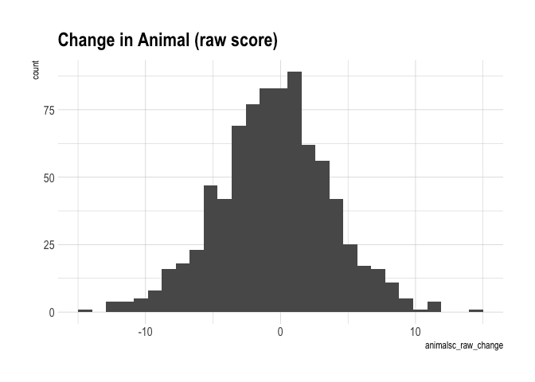

Summary table of change in Animal (raw score)

|  | n |
| --- | --- |
| -15 | 1 |
| -12 | 4 |
| -11 | 4 |
| -10 | 5 |
| -9 | 8 |
| -8 | 16 |
| -7 | 18 |
| -6 | 23 |
| -5 | 47 |
| -4 | 42 |
| -3 | 69 |
| -2 | 77 |
| -1 | 83 |
| 0 | 83 |
| 1 | 89 |
| 2 | 62 |
| 3 | 56 |
| 4 | 42 |
| 5 | 25 |
| 6 | 17 |
| 7 | 16 |
| 8 | 11 |
| 9 | 5 |
| 10 | 1 |
| 11 | 4 |
| 15 | 1 |
| NA | 1 |
| Total | 810 |

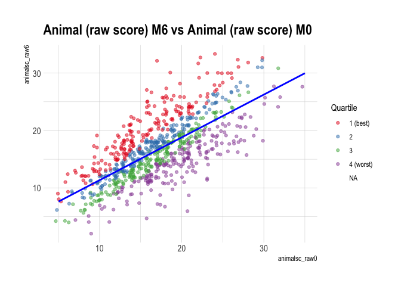

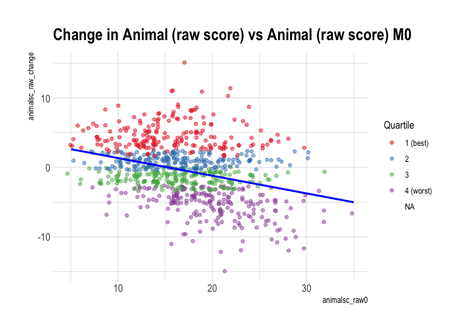

## Animal naming (categorical score)

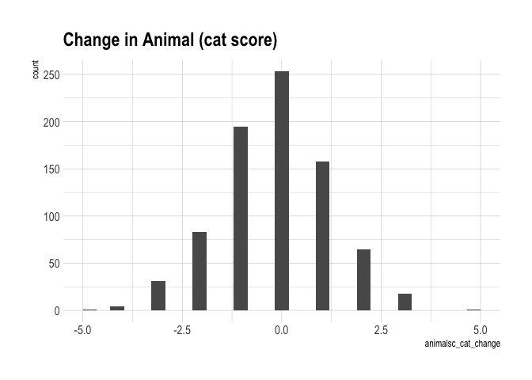

Summary table of change in Animal (cat score)

|  | n |
| --- | --- |
| -5 | 1 |
| -4 | 4 |
| -3 | 31 |
| -2 | 83 |
| -1 | 195 |
| 0 | 253 |
| 1 | 158 |
| 2 | 65 |
| 3 | 18 |
| 5 | 1 |
| NA | 1 |
| Total | 810 |

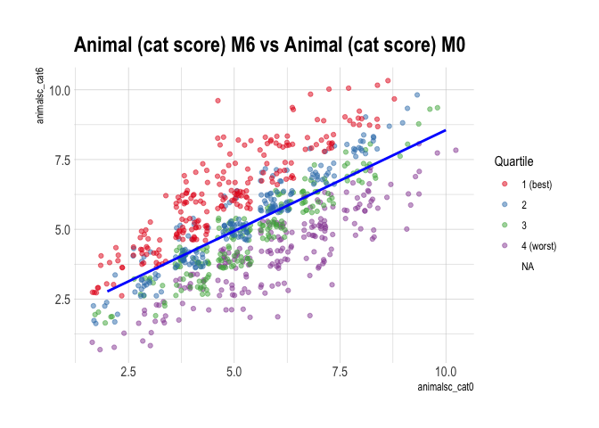

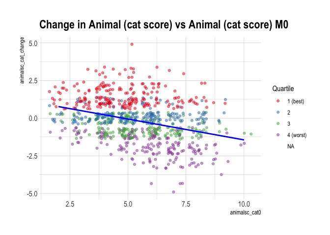

## F fluency (raw score)

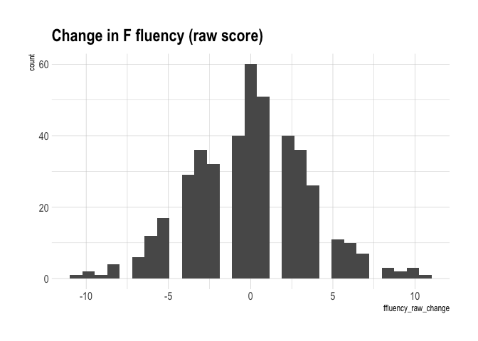

Summary table of change in F fluency (raw score)

|  | n |
| --- | --- |
| -11 | 1 |
| -10 | 2 |
| -9 | 1 |
| -8 | 4 |
| -7 | 6 |
| -6 | 12 |
| -5 | 17 |
| -4 | 29 |
| -3 | 36 |
| -2 | 32 |
| -1 | 40 |
| 0 | 60 |
| 1 | 51 |
| 2 | 40 |
| 3 | 36 |
| 4 | 26 |
| 5 | 11 |
| 6 | 10 |
| 7 | 7 |
| 8 | 3 |
| 9 | 2 |
| 10 | 3 |
| 11 | 1 |
| NA | 380 |
| Total | 810 |

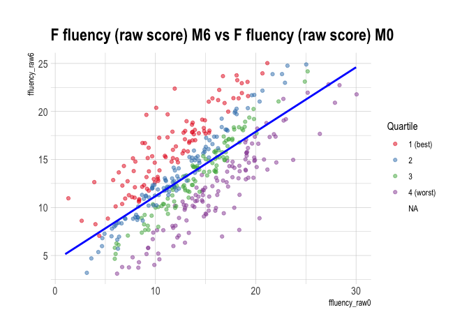

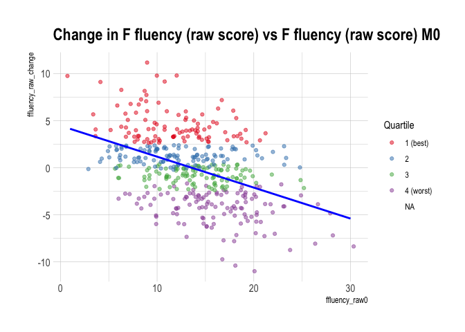

## F fluency (cat score)

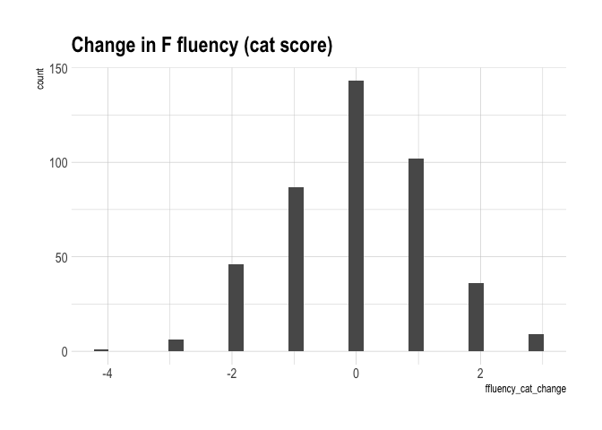

Summary table of change in F fluency (cat score)

|  | n |
| --- | --- |
| -4 | 1 |
| -3 | 6 |
| -2 | 46 |
| -1 | 87 |
| 0 | 143 |
| 1 | 102 |
| 2 | 36 |
| 3 | 9 |
| NA | 380 |
| Total | 810 |

[figure not shown]

[figure not shown]

## Confrontational naming

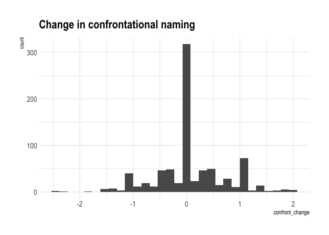

Summary table of Change in confrontational naming

|  | n |
| --- | --- |
| (-2.41,-2.26] | 3 |
| (-1.96,-1.81] | 1 |
| (-1.66,-1.51] | 6 |
| (-1.51,-1.37] | 7 |
| (-1.22,-1.07] | 18 |
| (-1.07,-0.921] | 27 |
| (-0.921,-0.772] | 15 |
| (-0.772,-0.624] | 17 |
| (-0.624,-0.475] | 28 |
| (-0.475,-0.327] | 47 |
| (-0.327,-0.178] | 37 |
| (-0.178,-0.03] | 15 |
| (-0.03,0.119] | 319 |
| (0.119,0.267] | 25 |
| (0.267,0.416] | 42 |
| (0.416,0.564] | 50 |
| (0.564,0.713] | 13 |
| (0.713,0.861] | 25 |
| (0.861,1.01] | 54 |
| (1.01,1.16] | 29 |
| (1.16,1.31] | 3 |
| (1.31,1.46] | 14 |
| (1.46,1.6] | 2 |
| (1.6,1.75] | 3 |
| (1.75,1.9] | 3 |
| (1.9,2.05] | 6 |
| NA | 1 |
| Total | 810 |

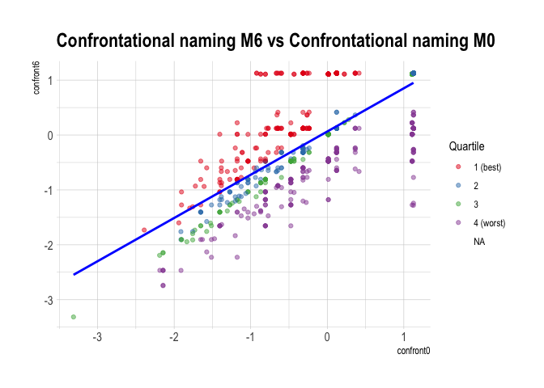

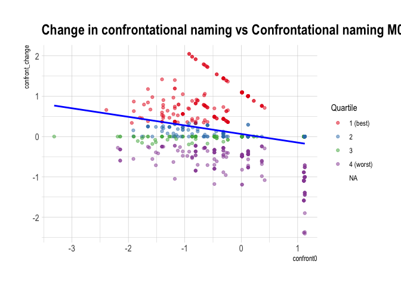

## Other language items

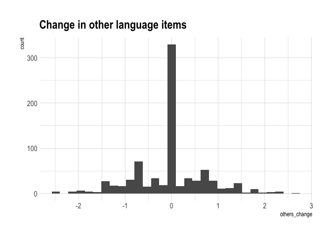

Summary table of Change in other language items

|  | n |
| --- | --- |
| (-2.57,-2.39] | 4 |
| (-2.22,-2.04] | 4 |
| (-2.04,-1.87] | 7 |
| (-1.87,-1.7] | 4 |
| (-1.7,-1.53] | 3 |
| (-1.53,-1.36] | 26 |
| (-1.36,-1.19] | 18 |
| (-1.19,-1.01] | 14 |
| (-1.01,-0.842] | 14 |
| (-0.842,-0.671] | 74 |
| (-0.671,-0.499] | 29 |
| (-0.499,-0.327] | 37 |
| (-0.327,-0.155] | 10 |
| (-0.155,0.0165] | 334 |
| (0.0165,0.188] | 15 |
| (0.188,0.36] | 26 |
| (0.36,0.532] | 28 |
| (0.532,0.704] | 23 |
| (0.704,0.875] | 62 |
| (0.875,1.05] | 13 |
| (1.05,1.22] | 11 |
| (1.22,1.39] | 14 |
| (1.39,1.56] | 17 |
| (1.56,1.73] | 4 |
| (1.73,1.91] | 9 |
| (1.91,2.08] | 3 |
| (2.08,2.25] | 2 |
| (2.25,2.42] | 3 |
| (2.42,2.6] | 1 |
| NA | 1 |
| Total | 810 |

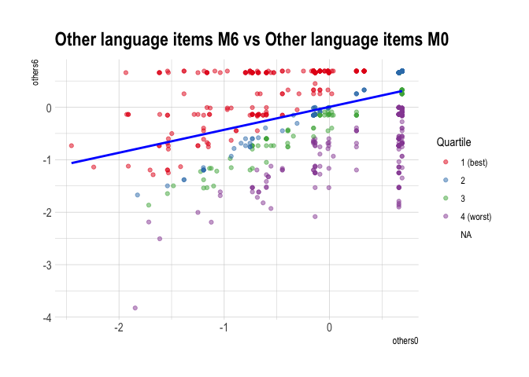

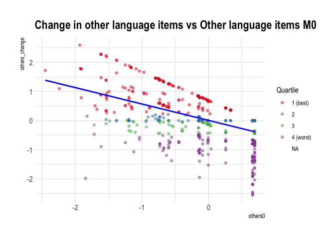

# Time to event analyses

This section examines the time to conversion for participants with MCI to AD.

## From MCI at baseline to AD

### Kaplan Meier curves

Kaplan Meier curves stratified by the quantiled change in test scores.

#### Individual language subdomains

Kaplan Meier curves of the retest improvement in individual language subdomains.

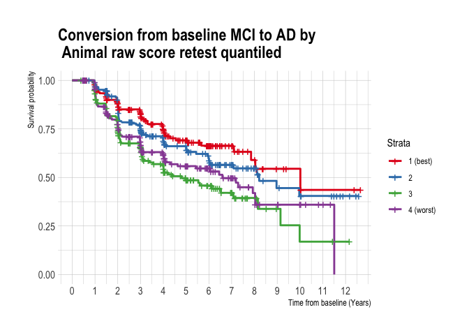

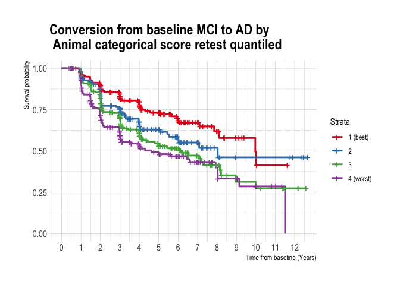

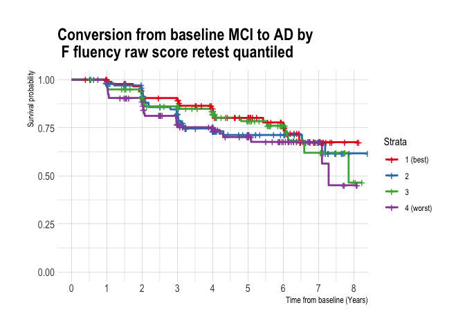

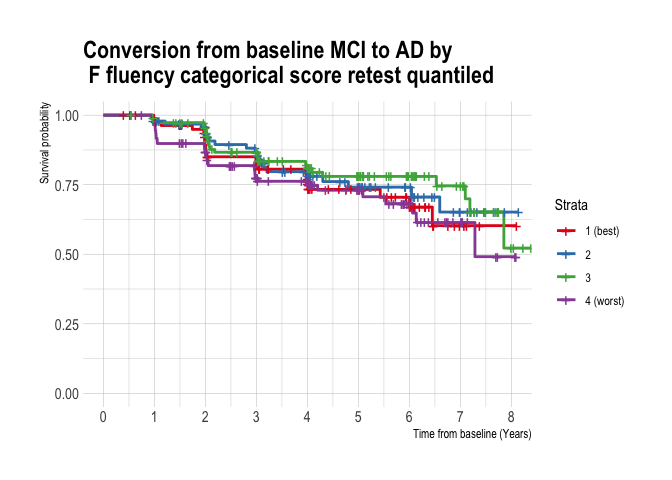

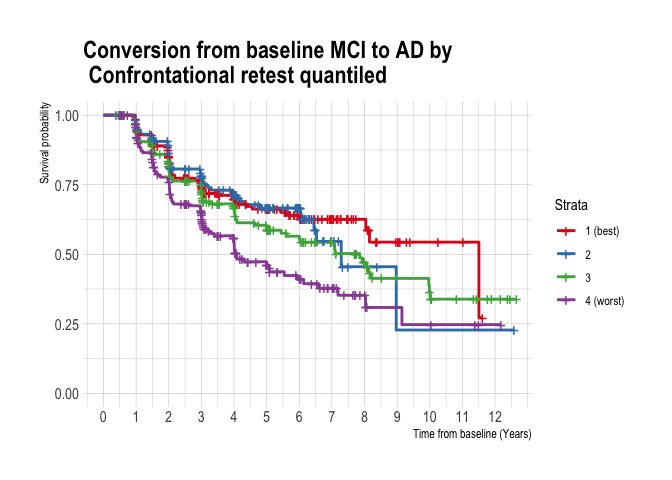

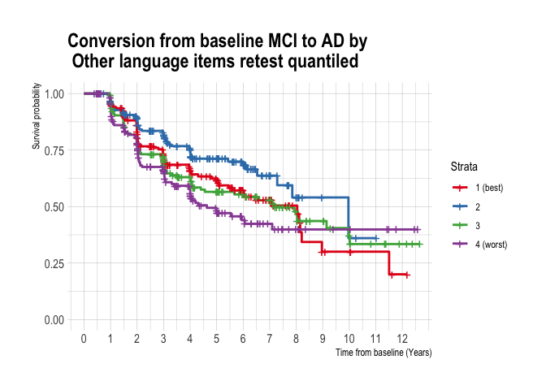

### Cox proportional hazards models

The reference group in the models is the first (best) quantile.

Cox proportional hazards model (Baseline MCI) - Animal fluency (raw score) Quartiles

| Predictor | HR | P-value |
| --- | --- | --- |
| anim_raw_q2 | 1.24 | 0.248 |
| anim_raw_q3 | 2.02 | 0.000 |
| anim_raw_q4 | 1.71 | 0.003 |

Cox proportional hazards model (Baseline MCI) - Animal fluency (categorical score) Quartiles

| Predictor | HR | P-value |
| --- | --- | --- |
| anim_cat_q2 | 1.44 | 0.052 |
| anim_cat_q3 | 1.87 | 0.000 |
| anim_cat_q4 | 2.33 | 0.000 |

Cox proportional hazards model (Baseline MCI) - F fluency (raw score) Quartiles

| Predictor | HR | P-value |
| --- | --- | --- |
| f_raw_q2 | 1.31 | 0.378 |
| f_raw_q3 | 1.17 | 0.616 |
| f_raw_q4 | 1.55 | 0.135 |

Cox proportional hazards model (Baseline MCI) - F fluency (categorical score) Quartiles

| Predictor | HR | P-value |
| --- | --- | --- |
| f_cat_q2 | 0.81 | 0.496 |
| f_cat_q3 | 0.74 | 0.311 |
| f_cat_q4 | 1.11 | 0.711 |

Cox proportional hazards model (Baseline MCI) - Confrontational Quartiles

| Predictor | HR | P-value |
| --- | --- | --- |
| confront_q2 | 1.02 | 0.904 |
| confront_q3 | 1.27 | 0.151 |
| confront_q4 | 1.84 | 0.000 |

Cox proportional hazards model (Baseline MCI) - Other language items Quartiles

| Predictor | HR | P-value |
| --- | --- | --- |
| others_q2 | 0.68 | 0.029 |
| others_q3 | 1.05 | 0.771 |
| others_q4 | 1.27 | 0.133 |

# Time to event comparison between retest effects and biomarkers

This section compares how well the learning effects predict MCI/AD conversion to conventional biomarkers (imaging and genetic) predicting MCI/AD conversion. The samples will be different for most of the analyses, because not all participants had all the biomarkers collected. For biomarkers measured multiple times we will use those from the 6 month visit.

The biomarkers we will compare are:

Models control for age, sex, and years of education.

## APOE 4

Any APOE 4 allele.

### MCI to AD

Any APOE 4 allele by conversion status

| Conversion | Any APOE 4 allele No | Any APOE 4 allele Yes |
| --- | --- | --- |
| 0 | 275 | 202 |
| 1 | 104 | 183 |

Cox proportional hazards model (Baseline MCI)

| Covariate | apoe4 HR (95% CI) | apoe4 p-value | Animals (categories) HR (95% CI) | Animals (categories) p-value | Animal (categories) + apoe4 HR (95% CI) | Animal (categories) + apoe4 p-value | Animals (raw scores) HR (95% CI) | Animals (raw scores) p-value | Animals (raw scores) + apoe4 HR (95% CI) | Animals (raw scores) + apoe4 p-value | Confrontational naming HR (95% CI) | Confrontational naming p-value | Confrontational naming + apoe4 HR (95% CI) | Confrontational naming + apoe4 p-value | Other Lang items HR (95% CI) | Other Lang items p-value | Other Lang items + apoe4 HR (95% CI) | Other Lang items + apoe4 p-value |
| --- | --- | --- | --- | --- | --- | --- | --- | --- | --- | --- | --- | --- | --- | --- | --- | --- | --- | --- |
| Biomarker |  |  |  |  |  |  |  |  |  |  |  |  |  |  |  |  |  |  |
| apoe4 | 2.56, (2.00, 3.28) | 0.000 |  |  | 2.57, (2.01, 3.29) | 0.000 |  |  | 2.51, (1.96, 3.22) | 0.000 |  |  | 2.51, (1.96, 3.21) | 0.000 |  |  | 2.55, (1.99, 3.26) | 0.000 |
| Animals (categorical) |  |  |  |  |  |  |  |  |  |  |  |  |  |  |  |  |  |  |
| anim_cat_q2 |  |  | 1.52, (1.05, 2.20) | 0.027 | 1.42, (0.98, 2.05) | 0.066 |  |  |  |  |  |  |  |  |  |  |  |  |
| anim_cat_q3 |  |  | 1.89, (1.35, 2.66) | 0.000 | 1.79, (1.27, 2.51) | 0.001 |  |  |  |  |  |  |  |  |  |  |  |  |
| anim_cat_q4 |  |  | 2.26, (1.61, 3.18) | 0.000 | 2.29, (1.63, 3.23) | 0.000 |  |  |  |  |  |  |  |  |  |  |  |  |
| Animals (raw score) |  |  |  |  |  |  |  |  |  |  |  |  |  |  |  |  |  |  |
| anim_raw_q2 |  |  |  |  |  |  | 1.19, (0.82, 1.71) | 0.359 | 1.24, (0.86, 1.78) | 0.253 |  |  |  |  |  |  |  |  |
| anim_raw_q3 |  |  |  |  |  |  | 1.99, (1.41, 2.82) | 0.000 | 1.87, (1.32, 2.65) | 0.000 |  |  |  |  |  |  |  |  |
| anim_raw_q4 |  |  |  |  |  |  | 1.65, (1.16, 2.34) | 0.005 | 1.71, (1.21, 2.44) | 0.003 |  |  |  |  |  |  |  |  |
| Confrontational |  |  |  |  |  |  |  |  |  |  |  |  |  |  |  |  |  |  |
| confront_q2 |  |  |  |  |  |  |  |  |  |  | 1.06, (0.73, 1.53) | 0.751 | 1.12, (0.77, 1.62) | 0.551 |  |  |  |  |
| confront_q3 |  |  |  |  |  |  |  |  |  |  | 1.29, (0.93, 1.79) | 0.129 | 1.31, (0.94, 1.82) | 0.107 |  |  |  |  |
| confront_q4 |  |  |  |  |  |  |  |  |  |  | 1.76, (1.28, 2.42) | 0.000 | 1.69, (1.23, 2.33) | 0.001 |  |  |  |  |
| Other Lang items |  |  |  |  |  |  |  |  |  |  |  |  |  |  |  |  |  |  |
| others_q2 |  |  |  |  |  |  |  |  |  |  |  |  |  |  | 0.71, (0.50, 1.01) | 0.057 | 0.75, (0.53, 1.07) | 0.111 |
| others_q3 |  |  |  |  |  |  |  |  |  |  |  |  |  |  | 1.00, (0.73, 1.38) | 0.991 | 1.04, (0.75, 1.42) | 0.832 |
| others_q4 |  |  |  |  |  |  |  |  |  |  |  |  |  |  | 1.24, (0.90, 1.69) | 0.185 | 1.27, (0.93, 1.74) | 0.131 |
| Covariates |  |  |  |  |  |  |  |  |  |  |  |  |  |  |  |  |  |  |
| agebl | 1.04, (1.03, 1.06) | 0.000 | 1.03, (1.01, 1.05) | 0.000 | 1.04, (1.02, 1.06) | 0.000 | 1.03, (1.02, 1.05) | 0.000 | 1.04, (1.02, 1.06) | 0.000 | 1.03, (1.01, 1.05) | 0.001 | 1.04, (1.02, 1.06) | 0.000 | 1.03, (1.01, 1.05) | 0.001 | 1.04, (1.02, 1.06) | 0.000 |
| ptsex | 1.16, (0.91, 1.48) | 0.241 | 1.09, (0.85, 1.39) | 0.491 | 1.16, (0.91, 1.49) | 0.228 | 1.05, (0.82, 1.33) | 0.715 | 1.13, (0.89, 1.45) | 0.316 | 1.06, (0.83, 1.35) | 0.663 | 1.13, (0.88, 1.45) | 0.321 | 1.06, (0.83, 1.35) | 0.623 | 1.15, (0.90, 1.47) | 0.256 |
| pteducat | 1.00, (0.96, 1.05) | 0.827 | 1.00, (0.96, 1.05) | 0.840 | 1.01, (0.97, 1.05) | 0.623 | 1.00, (0.96, 1.04) | 0.964 | 1.01, (0.97, 1.05) | 0.709 | 0.99, (0.95, 1.04) | 0.767 | 1.00, (0.96, 1.04) | 0.931 | 1.00, (0.96, 1.04) | 0.941 | 1.01, (0.96, 1.05) | 0.779 |

Reference category for the retest domains is the first quartile (best retest)

Summary statistics for Cox models

| Model | n | concordance |
| --- | --- | --- |
| Biomarker |  |  |
| apoe4 | 764 | 0.65 |
| Animal fluency (raw score) |  |  |
| Animal (raw score) | 764 | 0.59 |
| Animal (raw score) + apoe4 | 764 | 0.66 |
| Animal fluency (categorial) |  |  |
| Animal (categorical) | 764 | 0.61 |
| Animal (categorical) + apoe4 | 764 | 0.67 |
| Confrontational |  |  |
| Confrontational | 764 | 0.59 |
| Confrontational + apoe4 | 764 | 0.66 |
| Other Language items |  |  |
| Other language items | 764 | 0.58 |
| Other language items + apoe4 | 764 | 0.65 |

## CSF AD signature

CSF AD signature from De Meyer (2010)

### MCI to AD

CSF AD signature by conversion status

| Conversion | CSF AD signature No | CSF AD signature Yes | CSF AD signature Missing |
| --- | --- | --- | --- |
| 0 | 33 | 41 | 403 |
| 1 | 15 | 84 | 188 |

| Covariate | cluster_mixtmodel HR (95% CI) | cluster_mixtmodel p-value | Animals (categories) HR (95% CI) | Animals (categories) p-value | Animal (categories) + cluster_mixtmodel HR (95% CI) | Animal (categories) + cluster_mixtmodel p-value | Animals (raw scores) HR (95% CI) | Animals (raw scores) p-value | Animals (raw scores) + cluster_mixtmodel HR (95% CI) | Animals (raw scores) + cluster_mixtmodel p-value | Confrontational naming HR (95% CI) | Confrontational naming p-value | Confrontational naming + cluster_mixtmodel HR (95% CI) | Confrontational naming + cluster_mixtmodel p-value | Other Lang items HR (95% CI) | Other Lang items p-value | Other Lang items + cluster_mixtmodel HR (95% CI) | Other Lang items + cluster_mixtmodel p-value |
| --- | --- | --- | --- | --- | --- | --- | --- | --- | --- | --- | --- | --- | --- | --- | --- | --- | --- | --- |
| Biomarker |  |  |  |  |  |  |  |  |  |  |  |  |  |  |  |  |  |  |
| cluster_mixtmodel | 3.33, (1.90, 5.86) | 0.000 |  |  | 2.88, (1.62, 5.12) | 0.000 |  |  | 3.22, (1.82, 5.70) | 0.000 |  |  | 3.13, (1.76, 5.54) | 0.000 |  |  | 3.39, (1.92, 5.99) | 0.000 |
| Animals (categorical) |  |  |  |  |  |  |  |  |  |  |  |  |  |  |  |  |  |  |
| anim_cat_q2 |  |  | 2.05, (1.06, 3.94) | 0.032 | 1.62, (0.83, 3.15) | 0.156 |  |  |  |  |  |  |  |  |  |  |  |  |
| anim_cat_q3 |  |  | 1.18, (0.61, 2.26) | 0.628 | 1.13, (0.58, 2.21) | 0.714 |  |  |  |  |  |  |  |  |  |  |  |  |
| anim_cat_q4 |  |  | 2.56, (1.47, 4.48) | 0.001 | 2.09, (1.19, 3.69) | 0.011 |  |  |  |  |  |  |  |  |  |  |  |  |
| Animals (raw score) |  |  |  |  |  |  |  |  |  |  |  |  |  |  |  |  |  |  |
| anim_raw_q2 |  |  |  |  |  |  | 1.56, (0.85, 2.87) | 0.150 | 1.48, (0.80, 2.72) | 0.212 |  |  |  |  |  |  |  |  |
| anim_raw_q3 |  |  |  |  |  |  | 1.88, (1.00, 3.52) | 0.051 | 1.90, (1.00, 3.59) | 0.049 |  |  |  |  |  |  |  |  |
| anim_raw_q4 |  |  |  |  |  |  | 2.28, (1.28, 4.08) | 0.005 | 2.01, (1.12, 3.62) | 0.020 |  |  |  |  |  |  |  |  |
| Confrontational |  |  |  |  |  |  |  |  |  |  |  |  |  |  |  |  |  |  |
| confront_q2 |  |  |  |  |  |  |  |  |  |  | 1.10, (0.49, 2.48) | 0.812 | 1.30, (0.57, 2.98) | 0.534 |  |  |  |  |
| confront_q3 |  |  |  |  |  |  |  |  |  |  | 0.84, (0.50, 1.44) | 0.535 | 0.86, (0.50, 1.47) | 0.573 |  |  |  |  |
| confront_q4 |  |  |  |  |  |  |  |  |  |  | 1.79, (1.03, 3.10) | 0.038 | 1.53, (0.88, 2.66) | 0.135 |  |  |  |  |
| Other Lang items |  |  |  |  |  |  |  |  |  |  |  |  |  |  |  |  |  |  |
| others_q2 |  |  |  |  |  |  |  |  |  |  |  |  |  |  | 1.31, (0.59, 2.88) | 0.504 | 1.21, (0.55, 2.68) | 0.634 |
| others_q3 |  |  |  |  |  |  |  |  |  |  |  |  |  |  | 0.87, (0.53, 1.43) | 0.581 | 0.97, (0.59, 1.61) | 0.911 |
| others_q4 |  |  |  |  |  |  |  |  |  |  |  |  |  |  | 1.26, (0.73, 2.17) | 0.402 | 1.44, (0.83, 2.50) | 0.196 |
| Covariates |  |  |  |  |  |  |  |  |  |  |  |  |  |  |  |  |  |  |
| agebl | 1.01, (0.98, 1.04) | 0.629 | 1.00, (0.97, 1.03) | 0.989 | 1.01, (0.98, 1.04) | 0.717 | 1.00, (0.98, 1.03) | 0.856 | 1.01, (0.98, 1.04) | 0.543 | 1.00, (0.97, 1.03) | 0.974 | 1.00, (0.97, 1.03) | 0.828 | 1.00, (0.97, 1.03) | 0.952 | 1.01, (0.98, 1.04) | 0.573 |
| ptsex | 1.26, (0.81, 1.97) | 0.303 | 1.33, (0.85, 2.08) | 0.205 | 1.31, (0.83, 2.08) | 0.250 | 1.17, (0.75, 1.84) | 0.491 | 1.16, (0.73, 1.84) | 0.536 | 1.27, (0.82, 1.96) | 0.284 | 1.25, (0.79, 1.98) | 0.334 | 1.28, (0.83, 1.98) | 0.261 | 1.28, (0.82, 2.00) | 0.279 |
| pteducat | 0.99, (0.93, 1.06) | 0.853 | 1.00, (0.93, 1.08) | 0.945 | 1.01, (0.94, 1.08) | 0.860 | 1.00, (0.93, 1.08) | 0.926 | 1.01, (0.94, 1.09) | 0.713 | 0.99, (0.92, 1.06) | 0.706 | 1.00, (0.93, 1.07) | 0.981 | 0.98, (0.91, 1.05) | 0.544 | 0.99, (0.92, 1.06) | 0.680 |

Reference category for the retest domains is the first quartile (best retest)

Summary statistics for Cox models

| Model | n | concordance |
| --- | --- | --- |
| Biomarker |  |  |
| csf | 173 | 0.61 |
| Animal fluency (raw score) |  |  |
| Animal (raw score) | 173 | 0.60 |
| Animal (raw score) + csf | 173 | 0.65 |
| Animal fluency (categorial) |  |  |
| Animal (categorical) | 173 | 0.60 |
| Animal (categorical) + csf | 173 | 0.65 |
| Confrontational |  |  |
| Confrontational | 173 | 0.59 |
| Confrontational + csf | 173 | 0.64 |
| Other Language items |  |  |
| Other language items | 173 | 0.57 |
| Other language items + csf | 173 | 0.63 |

## Entorhinal cortical thickness

The left and right thicknesses are averaged, and then z-scored. The z-scored used 2*SD in its standardization so that the effects are on the same scale as the cognitive domain quantiles.

### MCI to AD

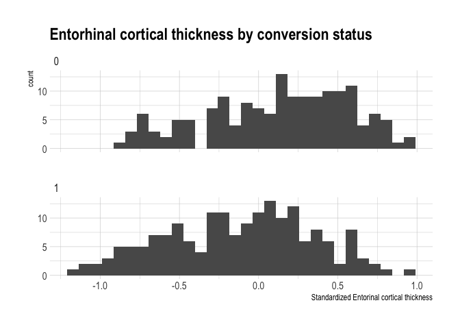

| Covariate | entorhinal_z HR (95% CI) | entorhinal_z p-value | Animals (categories) HR (95% CI) | Animals (categories) p-value | Animal (categories) + entorhinal_z HR (95% CI) | Animal (categories) + entorhinal_z p-value | Animals (raw scores) HR (95% CI) | Animals (raw scores) p-value | Animals (raw scores) + entorhinal_z HR (95% CI) | Animals (raw scores) + entorhinal_z p-value | Confrontational naming HR (95% CI) | Confrontational naming p-value | Confrontational naming + entorhinal_z HR (95% CI) | Confrontational naming + entorhinal_z p-value | Other Lang items HR (95% CI) | Other Lang items p-value | Other Lang items + entorhinal_z HR (95% CI) | Other Lang items + entorhinal_z p-value |
| --- | --- | --- | --- | --- | --- | --- | --- | --- | --- | --- | --- | --- | --- | --- | --- | --- | --- | --- |
| Biomarker |  |  |  |  |  |  |  |  |  |  |  |  |  |  |  |  |  |  |
| entorhinal_z | 0.31, (0.23, 0.43) | 0.000 |  |  | 0.32, (0.23, 0.44) | 0.000 |  |  | 0.33, (0.24, 0.45) | 0.000 |  |  | 0.33, (0.24, 0.46) | 0.000 |  |  | 0.32, (0.23, 0.45) | 0.000 |
| Animals (categorical) |  |  |  |  |  |  |  |  |  |  |  |  |  |  |  |  |  |  |
| anim_cat_q2 |  |  | 1.59, (0.93, 2.71) | 0.088 | 1.13, (0.65, 1.95) | 0.665 |  |  |  |  |  |  |  |  |  |  |  |  |
| anim_cat_q3 |  |  | 1.75, (1.12, 2.73) | 0.014 | 1.53, (0.97, 2.39) | 0.065 |  |  |  |  |  |  |  |  |  |  |  |  |
| anim_cat_q4 |  |  | 2.15, (1.40, 3.30) | 0.001 | 1.81, (1.17, 2.80) | 0.007 |  |  |  |  |  |  |  |  |  |  |  |  |
| Animals (raw score) |  |  |  |  |  |  |  |  |  |  |  |  |  |  |  |  |  |  |
| anim_raw_q2 |  |  |  |  |  |  | 1.42, (0.89, 2.26) | 0.136 | 1.29, (0.81, 2.06) | 0.279 |  |  |  |  |  |  |  |  |
| anim_raw_q3 |  |  |  |  |  |  | 2.41, (1.54, 3.79) | 0.000 | 2.09, (1.32, 3.32) | 0.002 |  |  |  |  |  |  |  |  |
| anim_raw_q4 |  |  |  |  |  |  | 1.83, (1.16, 2.89) | 0.009 | 1.77, (1.12, 2.79) | 0.014 |  |  |  |  |  |  |  |  |
| Confrontational |  |  |  |  |  |  |  |  |  |  |  |  |  |  |  |  |  |  |
| confront_q2 |  |  |  |  |  |  |  |  |  |  | 1.21, (0.63, 2.30) | 0.568 | 0.97, (0.51, 1.85) | 0.929 |  |  |  |  |
| confront_q3 |  |  |  |  |  |  |  |  |  |  | 0.82, (0.56, 1.21) | 0.314 | 0.79, (0.53, 1.16) | 0.232 |  |  |  |  |
| confront_q4 |  |  |  |  |  |  |  |  |  |  | 1.57, (1.05, 2.33) | 0.026 | 1.20, (0.79, 1.80) | 0.394 |  |  |  |  |
| Other Lang items |  |  |  |  |  |  |  |  |  |  |  |  |  |  |  |  |  |  |
| others_q2 |  |  |  |  |  |  |  |  |  |  |  |  |  |  | 0.83, (0.48, 1.43) | 0.497 | 0.91, (0.53, 1.57) | 0.729 |
| others_q3 |  |  |  |  |  |  |  |  |  |  |  |  |  |  | 0.65, (0.44, 0.96) | 0.031 | 0.76, (0.52, 1.12) | 0.169 |
| others_q4 |  |  |  |  |  |  |  |  |  |  |  |  |  |  | 0.94, (0.63, 1.39) | 0.741 | 0.91, (0.61, 1.36) | 0.660 |
| Covariates |  |  |  |  |  |  |  |  |  |  |  |  |  |  |  |  |  |  |
| agebl | 0.98, (0.96, 1.01) | 0.143 | 1.01, (0.99, 1.03) | 0.421 | 0.99, (0.96, 1.01) | 0.196 | 1.01, (0.99, 1.03) | 0.475 | 0.99, (0.97, 1.01) | 0.210 | 1.00, (0.98, 1.02) | 0.947 | 0.98, (0.96, 1.00) | 0.086 | 1.01, (0.99, 1.03) | 0.579 | 0.99, (0.96, 1.01) | 0.181 |
| ptsex | 1.25, (0.91, 1.71) | 0.163 | 1.27, (0.92, 1.74) | 0.147 | 1.23, (0.89, 1.69) | 0.204 | 1.18, (0.86, 1.63) | 0.300 | 1.18, (0.86, 1.63) | 0.307 | 1.13, (0.82, 1.55) | 0.449 | 1.18, (0.86, 1.62) | 0.306 | 1.28, (0.93, 1.75) | 0.132 | 1.28, (0.93, 1.76) | 0.123 |
| pteducat | 1.02, (0.97, 1.07) | 0.537 | 1.04, (0.99, 1.09) | 0.138 | 1.03, (0.98, 1.08) | 0.327 | 1.04, (0.99, 1.09) | 0.134 | 1.03, (0.98, 1.08) | 0.319 | 1.03, (0.98, 1.09) | 0.238 | 1.02, (0.97, 1.07) | 0.509 | 1.03, (0.98, 1.09) | 0.200 | 1.02, (0.97, 1.07) | 0.484 |

Reference category for the retest domains is the first quartile (best retest)

Summary statistics for Cox models

| Model | n | concordance |
| --- | --- | --- |
| Biomarker |  |  |
| entorhinal | 332 | 0.67 |
| Animal fluency (raw score) |  |  |
| Animal (raw score) | 332 | 0.61 |
| Animal (raw score) + entorhinal | 332 | 0.68 |
| Animal fluency (categorial) |  |  |
| Animal (categorical) | 332 | 0.59 |
| Animal (categorical) + entorhinal | 332 | 0.68 |
| Confrontational |  |  |
| Confrontational | 332 | 0.57 |
| Confrontational + entorhinal | 332 | 0.68 |
| Other Language items |  |  |
| Other language items | 332 | 0.56 |
| Other language items + entorhinal | 332 | 0.67 |

## Hippocampal volume (1.5T)

Hippocampal volume from 1.5T MRI (z-scored). The z-scored used 2*SD in its standardization so that the effects are on the same scale as the cognitive domain quantiles.

### MCI to AD

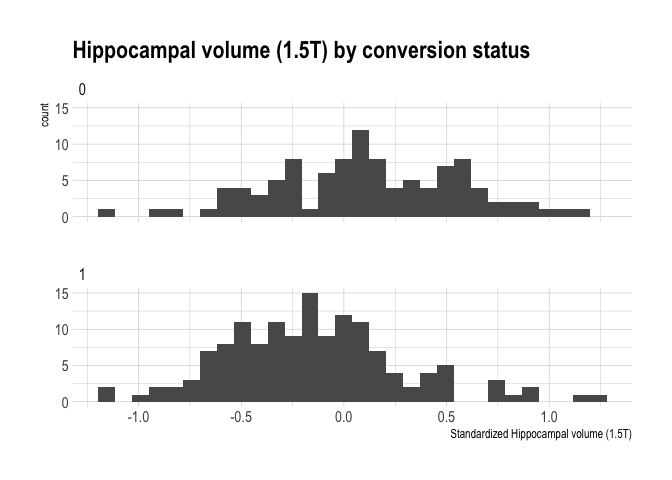

| Covariate | hcv_z HR (95% CI) | hcv_z p-value | Animals (categories) HR (95% CI) | Animals (categories) p-value | Animal (categories) + hcv_z HR (95% CI) | Animal (categories) + hcv_z p-value | Animals (raw scores) HR (95% CI) | Animals (raw scores) p-value | Animals (raw scores) + hcv_z HR (95% CI) | Animals (raw scores) + hcv_z p-value | Confrontational naming HR (95% CI) | Confrontational naming p-value | Confrontational naming + hcv_z HR (95% CI) | Confrontational naming + hcv_z p-value | Other Lang items HR (95% CI) | Other Lang items p-value | Other Lang items + hcv_z HR (95% CI) | Other Lang items + hcv_z p-value |
| --- | --- | --- | --- | --- | --- | --- | --- | --- | --- | --- | --- | --- | --- | --- | --- | --- | --- | --- |
| Biomarker |  |  |  |  |  |  |  |  |  |  |  |  |  |  |  |  |  |  |
| hcv_z | 0.24, (0.16, 0.37) | 0.000 |  |  | 0.25, (0.16, 0.38) | 0.000 |  |  | 0.25, (0.16, 0.39) | 0.000 |  |  | 0.24, (0.15, 0.38) | 0.000 |  |  | 0.26, (0.17, 0.41) | 0.000 |
| Animals (categorical) |  |  |  |  |  |  |  |  |  |  |  |  |  |  |  |  |  |  |
| anim_cat_q2 |  |  | 1.42, (0.77, 2.63) | 0.261 | 1.56, (0.84, 2.89) | 0.163 |  |  |  |  |  |  |  |  |  |  |  |  |
| anim_cat_q3 |  |  | 1.68, (1.03, 2.75) | 0.038 | 1.65, (1.00, 2.70) | 0.048 |  |  |  |  |  |  |  |  |  |  |  |  |
| anim_cat_q4 |  |  | 1.87, (1.16, 3.03) | 0.011 | 1.73, (1.06, 2.82) | 0.027 |  |  |  |  |  |  |  |  |  |  |  |  |
| Animals (raw score) |  |  |  |  |  |  |  |  |  |  |  |  |  |  |  |  |  |  |
| anim_raw_q2 |  |  |  |  |  |  | 1.29, (0.78, 2.11) | 0.320 | 1.06, (0.64, 1.75) | 0.819 |  |  |  |  |  |  |  |  |
| anim_raw_q3 |  |  |  |  |  |  | 2.09, (1.27, 3.44) | 0.004 | 1.64, (0.99, 2.72) | 0.056 |  |  |  |  |  |  |  |  |
| anim_raw_q4 |  |  |  |  |  |  | 1.59, (0.96, 2.62) | 0.071 | 1.38, (0.83, 2.30) | 0.209 |  |  |  |  |  |  |  |  |
| Confrontational |  |  |  |  |  |  |  |  |  |  |  |  |  |  |  |  |  |  |
| confront_q2 |  |  |  |  |  |  |  |  |  |  | 1.22, (0.61, 2.42) | 0.575 | 0.94, (0.47, 1.87) | 0.855 |  |  |  |  |
| confront_q3 |  |  |  |  |  |  |  |  |  |  | 0.82, (0.53, 1.26) | 0.358 | 0.79, (0.51, 1.22) | 0.287 |  |  |  |  |
| confront_q4 |  |  |  |  |  |  |  |  |  |  | 1.70, (1.08, 2.68) | 0.022 | 1.49, (0.94, 2.36) | 0.093 |  |  |  |  |
| Other Lang items |  |  |  |  |  |  |  |  |  |  |  |  |  |  |  |  |  |  |
| others_q2 |  |  |  |  |  |  |  |  |  |  |  |  |  |  | 1.50, (0.72, 3.10) | 0.275 | 1.26, (0.60, 2.63) | 0.540 |
| others_q3 |  |  |  |  |  |  |  |  |  |  |  |  |  |  | 0.56, (0.37, 0.84) | 0.006 | 0.67, (0.44, 1.02) | 0.061 |
| others_q4 |  |  |  |  |  |  |  |  |  |  |  |  |  |  | 0.84, (0.55, 1.30) | 0.432 | 0.82, (0.53, 1.27) | 0.370 |
| Covariates |  |  |  |  |  |  |  |  |  |  |  |  |  |  |  |  |  |  |
| agebl | 0.98, (0.96, 1.01) | 0.188 | 1.02, (0.99, 1.04) | 0.142 | 0.99, (0.96, 1.02) | 0.406 | 1.02, (0.99, 1.04) | 0.133 | 0.99, (0.96, 1.01) | 0.362 | 1.01, (0.98, 1.03) | 0.625 | 0.98, (0.95, 1.00) | 0.090 | 1.01, (0.99, 1.03) | 0.388 | 0.98, (0.96, 1.01) | 0.169 |
| ptsex | 0.96, (0.66, 1.38) | 0.821 | 1.42, (1.00, 2.02) | 0.053 | 1.00, (0.69, 1.45) | 0.999 | 1.32, (0.92, 1.88) | 0.127 | 0.93, (0.63, 1.36) | 0.701 | 1.20, (0.85, 1.71) | 0.303 | 0.84, (0.58, 1.23) | 0.367 | 1.45, (1.02, 2.06) | 0.039 | 1.01, (0.70, 1.47) | 0.942 |
| pteducat | 1.01, (0.95, 1.07) | 0.748 | 1.02, (0.96, 1.08) | 0.477 | 1.02, (0.96, 1.08) | 0.582 | 1.02, (0.96, 1.08) | 0.491 | 1.02, (0.96, 1.08) | 0.613 | 1.02, (0.96, 1.08) | 0.599 | 1.01, (0.95, 1.07) | 0.767 | 1.01, (0.95, 1.07) | 0.680 | 1.01, (0.95, 1.07) | 0.697 |

Reference category for the retest domains is the first quartile (best retest)

Summary statistics for Cox models

| Model | n | concordance |
| --- | --- | --- |
| Biomarker |  |  |
| hippocampal | 245 | 0.67 |
| Animal fluency (raw score) |  |  |
| Animal (raw score) | 245 | 0.59 |
| Animal (raw score) + hippocampal | 245 | 0.68 |
| Animal fluency (categorial) |  |  |
| Animal (categorical) | 245 | 0.58 |
| Animal (categorical) + hippocampal | 245 | 0.68 |
| Confrontational |  |  |
| Confrontational | 245 | 0.60 |
| Confrontational + hippocampal | 245 | 0.67 |
| Other Language items |  |  |
| Other language items | 245 | 0.59 |
| Other language items + hippocampal | 245 | 0.67 |

# R technical details

Details about the R session used to create this report.

R version 3.6.2 (2019-12-12) Platform: x86_64-apple-darwin15.6.0 (64-bit) Running under: macOS Mojave 10.14.6

Matrix products: default BLAS: /Library/Frameworks/R.framework/Versions/3.6/Resources/lib/libRblas.0.dylib LAPACK: /Library/Frameworks/R.framework/Versions/3.6/Resources/lib/libRlapack.dylib

Random number generation: RNG: Mersenne-Twister Normal: Inversion Sample: Rounding

locale: [1] en_US.UTF-8/en_US.UTF-8/en_US.UTF-8/C/en_US.UTF-8/en_US.UTF-8

attached base packages: [1] stats graphics grDevices utils datasets methods base

other attached packages: [1] glue_1.4.0 gt_0.1.0 broom_0.7.0 survminer_0.4.8  
[5] ggpubr_0.4.0 survival_3.1-11 gghighlight_0.3.0 rlang_0.4.5  
[9] kableExtra_1.1.0 haven_2.2.0 fs_1.3.2 here_0.1  
[13] forcats_0.5.0 stringr_1.4.0 dplyr_0.8.5 purrr_0.3.3  
[17] readr_1.3.1 tidyr_1.0.2 tibble_3.0.3 ggplot2_3.3.0  
[21] tidyverse_1.3.0

loaded via a namespace (and not attached): [1] nlme_3.1-145 lubridate_1.7.4 webshot_0.5.2 httr_1.4.1  
[5] rprojroot_1.3-2 tools_3.6.2 backports_1.1.5 R6_2.4.1  
[9] mgcv_1.8-31 DBI_1.1.0 colorspace_1.4-1 withr_2.1.2  
[13] tidyselect_1.0.0 gridExtra_2.3 curl_4.3 compiler_3.6.2  
[17] extrafontdb_1.0 cli_2.0.2 rvest_0.3.5 xml2_1.2.5  
[21] sass_0.2.0 labeling_0.3 checkmate_2.0.0 scales_1.1.0  
[25] survMisc_0.5.5 systemfonts_0.1.1 digest_0.6.25 foreign_0.8-76  
[29] rmarkdown_2.1 rio_0.5.16 pkgconfig_2.0.3 htmltools_0.4.0  
[33] extrafont_0.17 highr_0.8 dbplyr_1.4.2 readxl_1.3.1  
[37] rstudioapi_0.11 farver_2.0.3 generics_0.0.2 zoo_1.8-7  
[41] jsonlite_1.6.1 zip_2.0.4 car_3.0-7 magrittr_1.5  
[45] Matrix_1.2-18 Rcpp_1.0.4 munsell_0.5.0 fansi_0.4.1  
[49] abind_1.4-5 gdtools_0.2.1 lifecycle_0.2.0 stringi_1.4.6  
[53] yaml_2.2.1 carData_3.0-3 grid_3.6.2 hrbrthemes_0.8.0 [57] crayon_1.3.4 lattice_0.20-40 splines_3.6.2 hms_0.5.3  
[61] knitr_1.28 pillar_1.4.3 ggsignif_0.6.0 reprex_0.3.0  
[65] evaluate_0.14 data.table_1.12.8 modelr_0.1.6 vctrs_0.2.4  
[69] Rttf2pt1_1.3.8 cellranger_1.1.0 gtable_0.3.0 km.ci_0.5-2  
[73] assertthat_0.2.1 xfun_0.12 openxlsx_4.1.4 xtable_1.8-4  
[77] rstatix_0.6.0 viridisLite_0.3.0 KMsurv_0.1-5 ellipsis_0.3.0